## Example Summary

In this example you will learn how to build a time-synchronized connection between one transmitter and a receiver. Time-synchronization enables both communication partners to transfer data quickly at predictable time points. Unlike the wake-on-radio example, the transmitter does not need to send a very long preamble and the receiver does not need to wait and check for a signal on air. This leads to the lowest possible power consumption on both sides. It also fits very well to the SimpleLink Long-range mode. Time synchronization builds also the foundation for Frequency and Time Division Multiple Access, FDMA and TDMA respectively.

## Resources & Jumper Settings

This section explains the resource mapping across various boards. If you’re using an IDE (such as CCS or IAR), please refer to Board.html in your project directory for resources used and board-specific jumper settings. Otherwise, you can find Board.html in the directory <SDK_INSTALL_DIR>/source/ti/boards/<BOARD>.

### SmartRF06 in combination with one of the CC13x0 evaluation modules

[output not shown]

### CC1310 / CC1350 Launchpad

| Resource | Mapping / Notes |
| --- | --- |
| `BUTTON1` | `BTN-1` (left button) |
| `BUTTON2` | `BTN_2` (right button) |
| `LED1` | Green LED |
| `LED2` | Red LED |

## Example Usage

This section is similar for both TX and RX. You need 2 boards: one running the `rfSynchronizedPacketTx` application (TX board) and another one running the `rfSynchronizedPacketRx` application (RX board).

### Initial synchronization

1. Build and run the `rfSynchronizedPacketRx` example on the RX board. You will see `LED2` on the RX board being on all the time.
2. Build and run the `rfSynchronizedPacketTx` example on the TX board. You will see `LED2` on the TX board flashing with a period of 500 ms. On the RX board, you will see that `LED2` is flashing synchronously.
3. Push `BUTTON1` on the TX board. `LED1` will toggle immediately. On the RX board, `LED1` follows after a short delay.
4. You may push `BUTTON1` several times and will see that `LED1` on the RX board will always reflect the state on the TX board with some delay.

Explanation: After starting, the RX board goes into `WaitingForSync` state. The receiver is switched on end waits for a packet. The LNA signal (`LED2`) is enabled to reflect the current receiver state.

When the application on the TX board is started, it starts to send periodic beacon messages. Once the RX board has received the first beacon message, it switches the receiver off and goes into `SyncedRx` state. In this state, it wakes up the receiver right before the next packet from the TX board is expected.

When `BUTTON1` on the TX board is pushed, the current LED state is sent in the next available time slot and is shown on the RX board as soon as the packet has arrived.

### Sending spontaneous messages after synchronization

1. Push `BUTTON2` on the TX board. You will see that `LED2` on the TX board stops flashing while `LED2` on the RX boards remains flashing.
2. Push `BUTTON1` on the TX board. You will see that `LED1` toggles on the TX board and with a short delay also on the RX board. `LED2` on the TX board will flash a short while after pushing the button.

Explanation: After pushing `BUTTON2` on the TX board, the TX application goes into `SporadicMessage` state and stops sending periodic beacons. The RX application remains in `SyncedRx` state and wakes up when it expects a packet. As long as no button on the TX board is pushed, the RX board will wake up only for a short time and go back to standby after a very short timeout because no packet is received.

When pushing `BUTTON1` on the TX board, a packet with the new state of `LED1` is transmitted. The TX board sends exactly at the same time when the RX board expects to receive a packet. The RX board receives the message and updates the state of its own `LED1`.

### Error handling: Resynchronization due to crystal drift

Explanation: Both TX and RX board predict the following wake-up events based on the time when synchronization happened. If both clocks have a small drift, then the wake-up time will be incorrect after some time.

By pushing `BUTTON1` on the RX board, the application goes back into `WaitingForSync` state and re-synchronizes to the TX board.

## Application Design Details

This examples consists of a single task and the exported SmartRF Studio radio settings. The RX application is implemented as a state machine with 3 states:

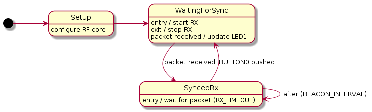

In order to send synchronous packets, the receiver uses absolute start triggers. Absolute start triggers are explained in the proprietary RF user’s guide and the technical reference manual.

In `WaitingForSync` state, the receiver waits an infinite time in RX state. That means, the power consumption is high. As soon as it receives a beacon packet from the transmitter and the packet is valid, it uses the RX time stamp as an anchor time:

```c
    /* rxTime contains a calculated time stamp when the first preamble byte
     * was sent on air. As a time base for the next wake ups, we calculate
     * the time when this RX command would have been started for a synchronised
     * wake up. */
    RF_cmdPropRx.startTime = rxTime - RX_START_TO_SETTLE_TICKS - RX_START_MARGIN;
```

The RX time stamp is the time when the first preamble bit was on air. The RF core calculates this time based on the internal “sync word found” signal and the RF settings provided in the SETUP command. The `RX_START_TO_SETTLE_TICKS` needs to be subtracted because it takes some time between command start and the receiver being ready to receive. In addition, `RX_START_MARGIN` is subtracted to start the RX operation a bit earlier. This is necessary to compensate possible crystal drifts.

Finally, the application goes into the `SyncedRx` state where it calculates the time for the next RX start based on the latest received packet:

```c
    /* Start RX command to receive a single packet. Use an absolute start trigger
     * and a predicted start time. The end time is calculated to be as tight as possible.
     * The compensation margin for RAT drift in both directions needs to be taken into account.  */
    RF_cmdPropRx.startTrigger.triggerType = TRIG_ABSTIME;
    RF_cmdPropRx.startTime += beacon.beaconInterval;
    RF_cmdPropRx.endTrigger.triggerType = TRIG_REL_START;
    RF_cmdPropRx.endTime = RX_START_TO_SETTLE_TICKS + RX_TIMEOUT_TICKS + RX_TIMEOUT_MARGIN + RX_START_MARGIN;
```

The RF driver takes care that the RF core is powered up and running before the start trigger is due. For the end trigger, we use a time relative to the command start. That means, the timeout is determined by:

- the time needed for transmitting a whole preamble and sync word,
- the margin subtracted from the start trigger,
- an additional timeout margin to compensate possible errors in the calculation